# Genome-wide methylation analysis report

# Genome-wide methylation analysis report

- study: Pleural cfDNAm analysis of infection.platevariable
- author: Paul Yousefi
- date: 08 October, 2026

## Parameters

```
## $sig.threshold
## [1] 2.121143e-07
##
## $max.plots
## [1] 10
##
## $qq.inflation.method
## [1] "median"
##
## $practical.threshold
## [1] 1.822769e-05
```

## Sample characteristics

For continuous or ordinal variables, the “mean” column provides the mean and the “sd/%” column the standard deviation of the variable. For categorical variables, the “mean” column provides the number of samples with the given “value” and the “sd/%” column the percentage of samples with the given “value”.

| variable | value | mean | sd.. |
| --- | --- | --- | --- |
| infection |  | 0.1172638 | 0.3222597 |
| plate |  | 2.319218 | 1.048991 |
| sv1 |  | 1.173243e-18 | 0.0571662 |
| sv2 |  | 6.138809e-19 | 0.0571662 |
| sv3 |  | -1.103626e-20 | 0.0571662 |
| sv4 |  | 3.666061e-18 | 0.0571662 |
| sv5 |  | 2.499426e-18 | 0.0571662 |
| sv6 |  | 1.013526e-18 | 0.0571662 |
| sv7 |  | -4.039216e-19 | 0.0571662 |
| sv8 |  | 1.757036e-15 | 0.0571662 |
| sv9 |  | 4.226328e-14 | 0.0571662 |
| sv10 |  | 1.505571e-12 | 0.0571662 |

## Covariate associations

### Covariate plate

statistics

| var1 | var2 | F | p-value | R | p-value |
| --- | --- | --- | --- | --- | --- |
| infection | plate | 2.598832 | 0.1079768 | 0.0935604 | 0.1017948 |

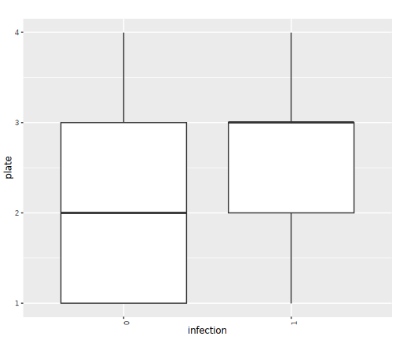

### Covariate sv1

statistics

| var1 | var2 | F | p-value | R | p-value |
| --- | --- | --- | --- | --- | --- |
| infection | sv1 | 2.125333 | 0.1459101 | -0.0828241 | 0.1476831 |

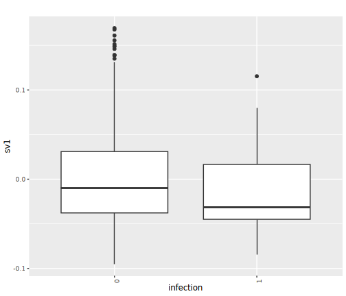

### Covariate sv2

statistics

| var1 | var2 | F | p-value | R | p-value |
| --- | --- | --- | --- | --- | --- |
| infection | sv2 | 0.0230421 | 0.879448 | -0.0173645 | 0.7618652 |

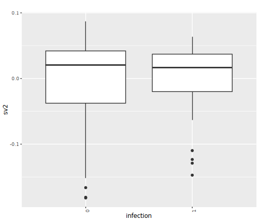

### Covariate sv3

statistics

| var1 | var2 | F | p-value | R | p-value |
| --- | --- | --- | --- | --- | --- |
| infection | sv3 | 1.028489 | 0.3113176 | -0.0740276 | 0.19582 |

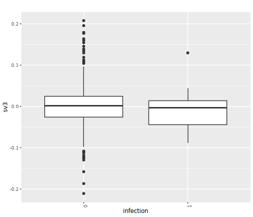

### Covariate sv4

statistics

| var1 | var2 | F | p-value | R | p-value |
| --- | --- | --- | --- | --- | --- |
| infection | sv4 | 0.4092432 | 0.5228341 | 0.0322157 | 0.573906 |

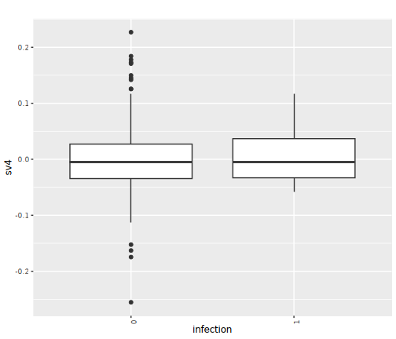

### Covariate sv5

statistics

| var1 | var2 | F | p-value | R | p-value |
| --- | --- | --- | --- | --- | --- |
| infection | sv5 | 0.554094 | 0.4572228 | 0.04661 | 0.415769 |

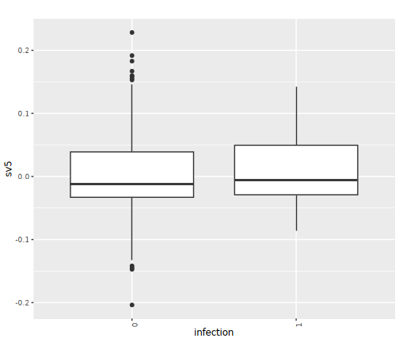

### Covariate sv6

statistics

| var1 | var2 | F | p-value | R | p-value |
| --- | --- | --- | --- | --- | --- |
| infection | sv6 | 0.4268087 | 0.5140512 | -0.0621466 | 0.2776983 |

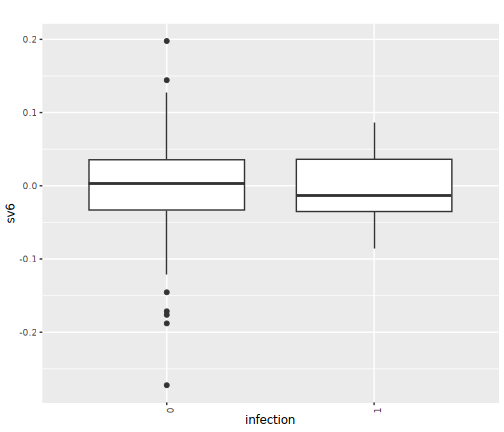

### Covariate sv7

statistics

| var1 | var2 | F | p-value | R | p-value |
| --- | --- | --- | --- | --- | --- |
| infection | sv7 | 0.7452074 | 0.3886761 | 0.0678586 | 0.2358214 |

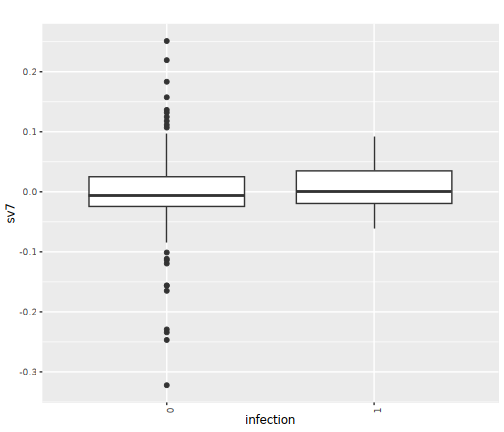

### Covariate sv8

statistics

| var1 | var2 | F | p-value | R | p-value |
| --- | --- | --- | --- | --- | --- |
| infection | sv8 | 0.0023543 | 0.9613323 | 0.017136 | 0.7649061 |

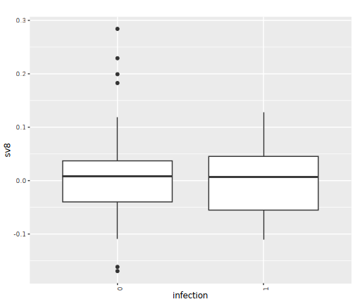

### Covariate sv9

statistics

| var1 | var2 | F | p-value | R | p-value |
| --- | --- | --- | --- | --- | --- |
| infection | sv9 | 0.8958621 | 0.3446429 | 0.0389559 | 0.4964817 |

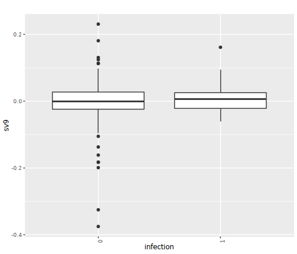

### Covariate sv10

statistics

| var1 | var2 | F | p-value | R | p-value |
| --- | --- | --- | --- | --- | --- |
| infection | sv10 | 1.470503 | 0.2262048 | 0.0504941 | 0.3779487 |

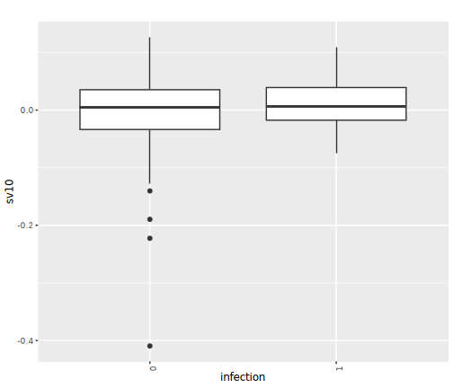

## QQ plots

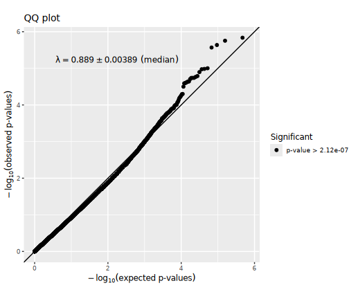

## Manhattan plots

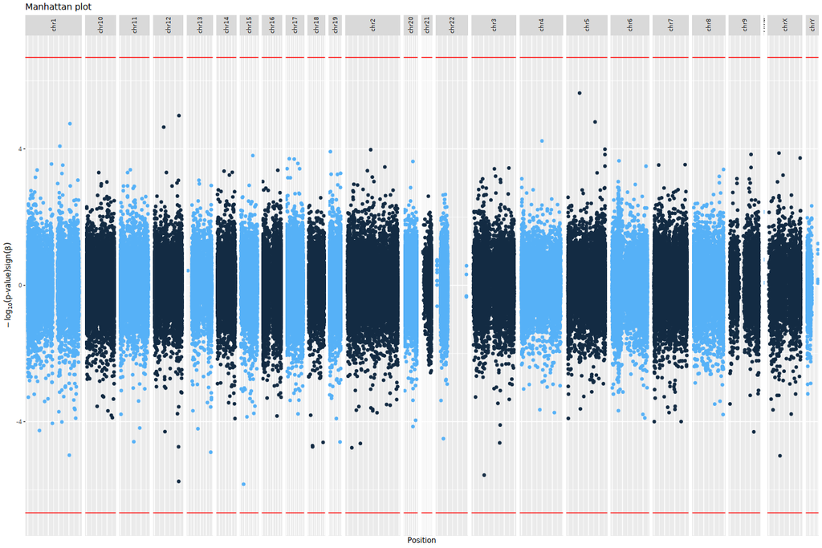

## Significant CpG sites

There were 0 CpG sites with association p-values < 2.1211427 × 10<sup>-7</sup>. These are listed in the file associations.csv.

Below are the 10 CpG sites with association p-values < 1.8227689 × 10<sup>-5</sup> in the regression model.

[output not shown]

Plots of these sites follow, one for each covariate set. “p[lm]” denotes the p-value obtained using a linear model and “p[beta]” the p-value obtained using beta regression.

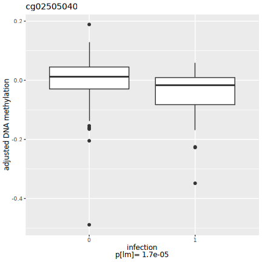

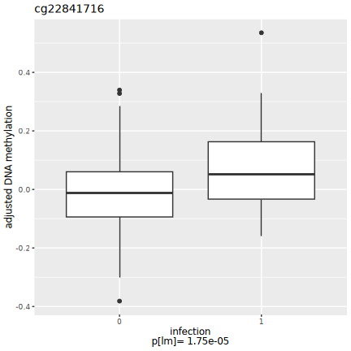

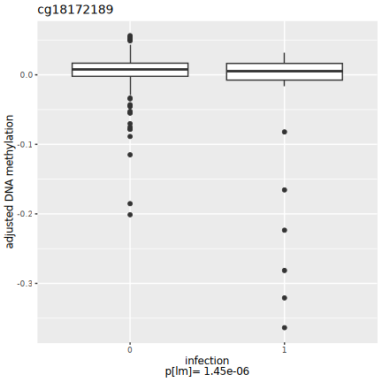

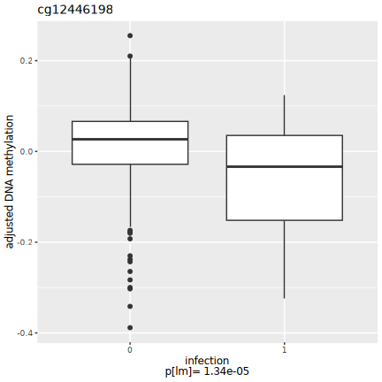

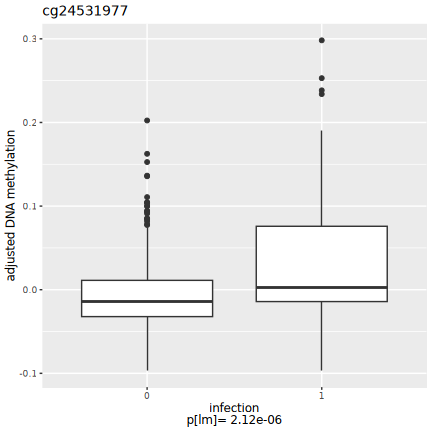

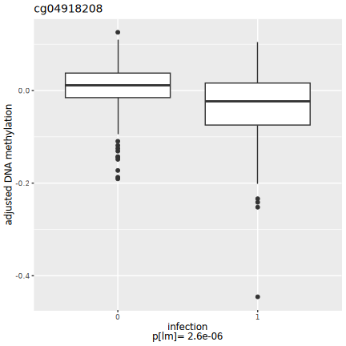

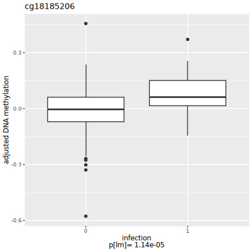

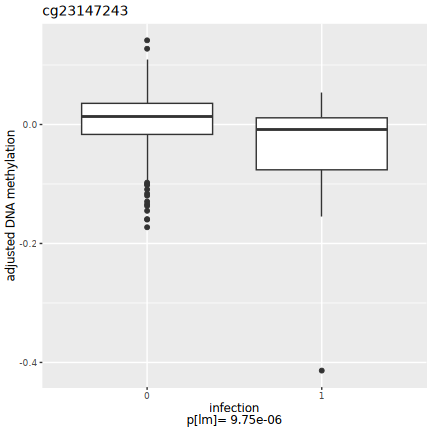

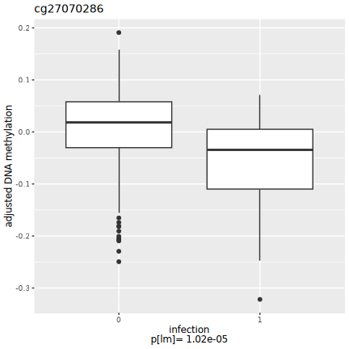

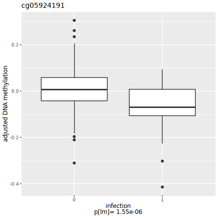

## Selected CpG sites

Number of CpG sites selected: 0.

| chromosome | position | estimate | p.value | p.adjust |
| --- | --- | --- | --- | --- |